# Socio-economic & Physical Impact of COVID-19

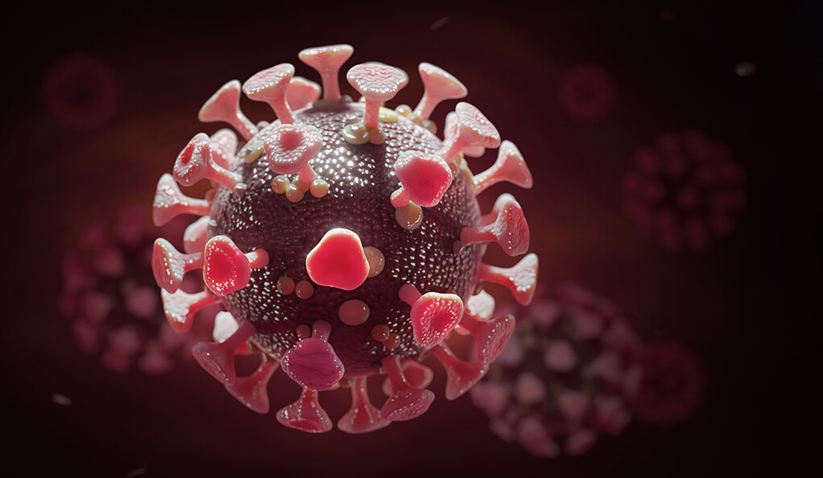

**COVID-19 (Coronavirus) has affected day to day life and is slowing down the global economy. This pandemic has affected thousands of peoples, who are either sick or are being killed due to the spread of this disease. The most common symptoms of this viral infection are fever, cold, cough, bone pain and breathing problems, and ultimately leading to pneumonia. This, being a new viral disease affecting humans for the first time, vaccines are not yet available. From shifting to online mode of communication and travel restrictions to deterioration in mental health and increase in substance abuses. COVID-19 has presented itself with new challenges and through this report we will assess the socio-economic impact based on data from the Associate Press for the period between April-June 2020.**

# Social Impact of COVID-19

The COVID-19 pandemic in the United States has had far-reaching consequences in the country that go beyond the spread of the disease itself in efforts to control it. One of the major impact is it’s effect on the social well being of people.

The below graphs represents the change in the frequency of interaction among family and friends due to COVID-19

### Social Interactions data Before COVID-19

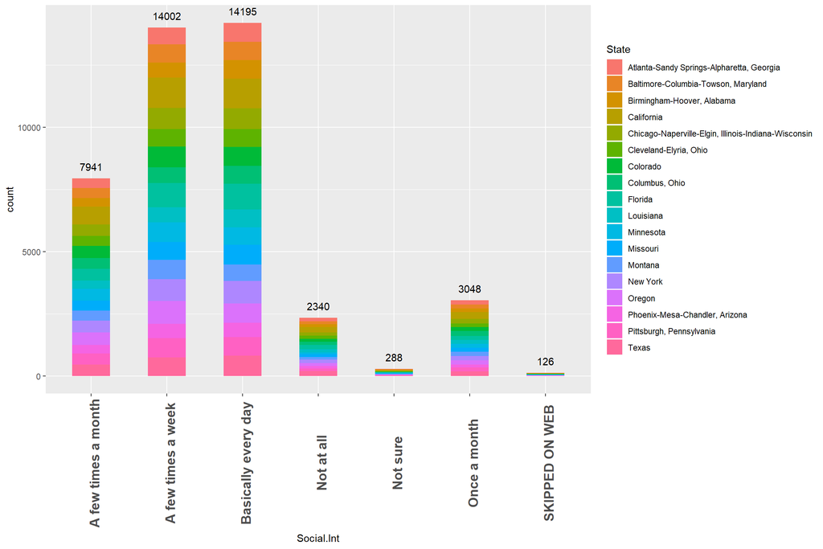

- The above graph shows the statistics of the frequentcy at which people interact with their friends and family before Covid-19
- The population count for this study was 41940
- A mix response was received from all the sates, with the category “Basically every day” chosen by 14195 individuals, being the most common choice of the residents, followed by “A few time a week” by 14002 number of people
- The third most popular response was “A few times a month” at count 7941

### Social Interactions Data Post COVID-19 Outbreak

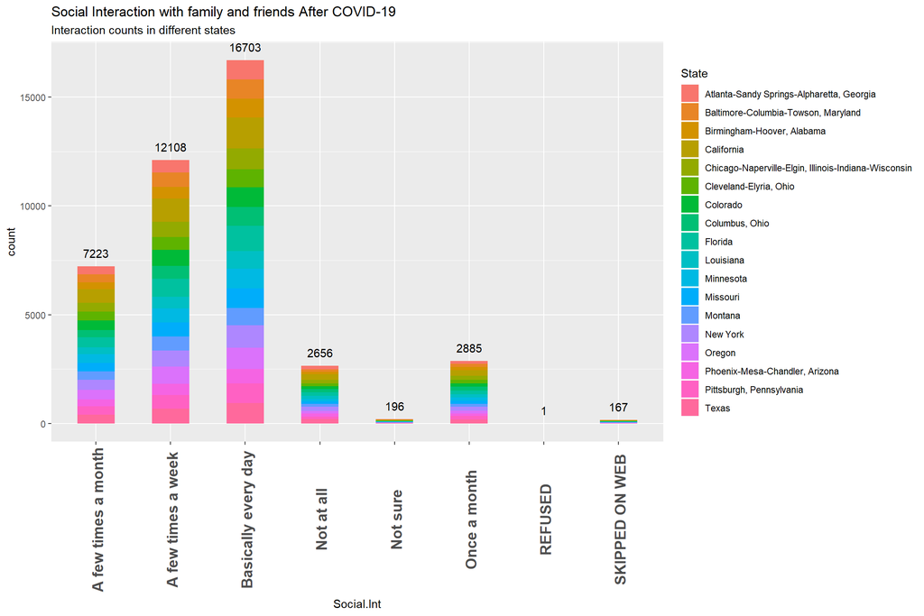

- The above graph shows the impact of covid19 on the social interaction among friends and family during April to June,2020
- The population count for this study was 41940
- A mix response was received from all the sates, with the category “Basically every day” chosen by 16703 individuals, being the most common choice of the residents, followed by “A few time a week” by 12108 number of people
- The third most popular response was “A few times a month” at count 7223

# Physical Impact of COVID-19

The COVID-19 pandemic in the United States had an huge impact on the physical health of the people due the physical impact of contracting the disease and due to lockdown and restrictions imposed by the government. An outcome of these restrictions is limited physical exercise. The below graphs represents the change in the physical health of people due to COVID-19. Factors like fever, chills, cough etc where studied.

### Physical Impact Before COVID-19 Outbreak

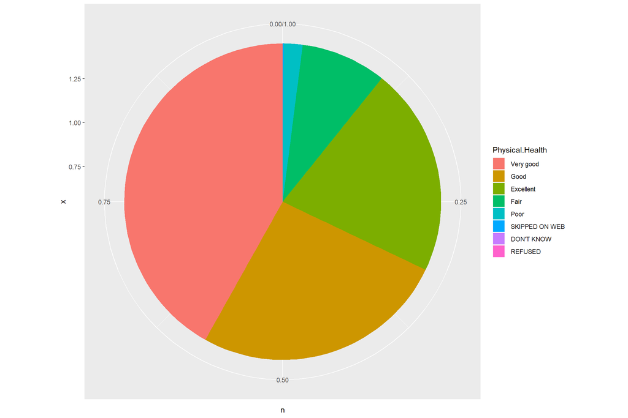

### Physical Impact Post COVID-19 Outbreak

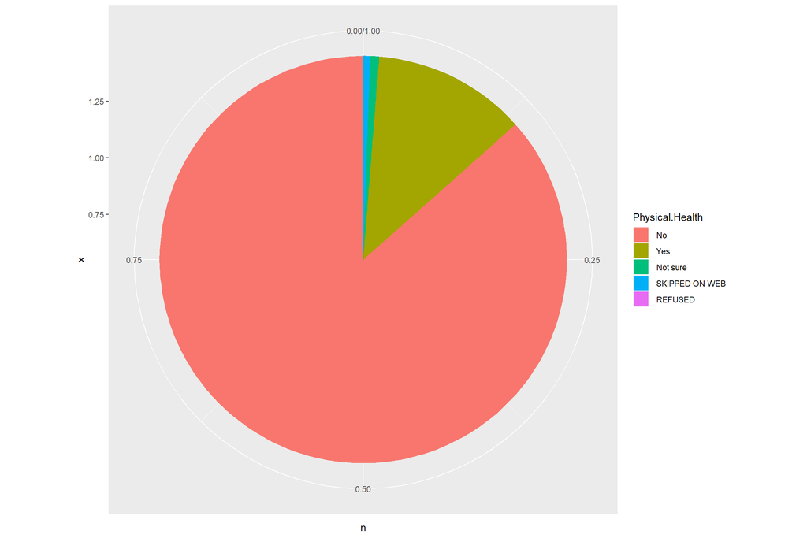

- The above graph shows the statistics of the physical health of people after the Covid-19 outbreak, during April to June,2020
- The population count for this study was 377460 and were asked if they have been feeling unwell or having covid symptoms in the past week
- A skewed response was received from all the states, with the category “No” chosen by 326696 i.e. 86.5% of the total poluplation
- The second most common choice was “Yes”, by 46039 people

# Impact of COVID-19 on the Mental Health

The coronavirus disease 2019 (COVID-19) pandemic may be stressful for people. Fear and anxiety about a new disease and what could happen can be overwhelming and cause strong emotions in adults and children.

Public health actions, such as social distancing, can make people feel isolated and lonely and can increase stress and anxiety. However, these actions are necessary to reduce the spread of COVID-19. To study the mental health impact of COVID-19, a population count of 101076 were surveyed for any mental health concerns like depression.

The below graphs represent the social and physical reactions during the covid outbreak.

### Social Reactions

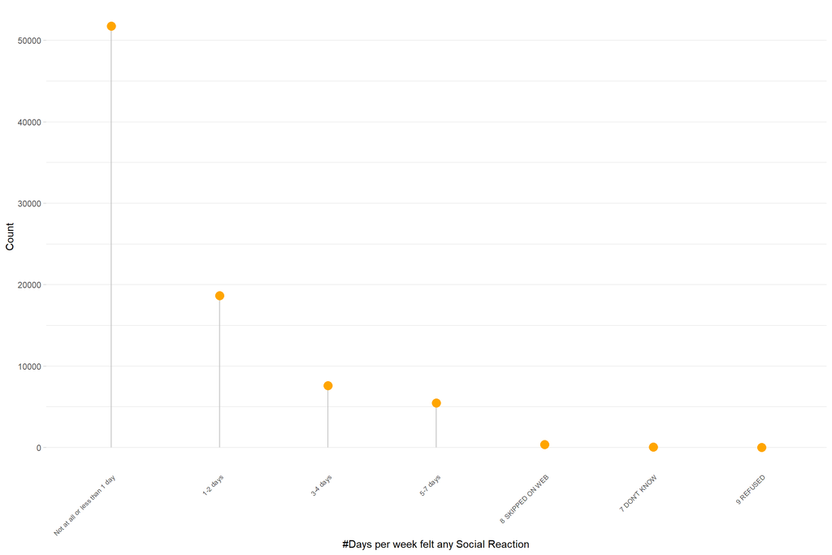

### Physical Reactions

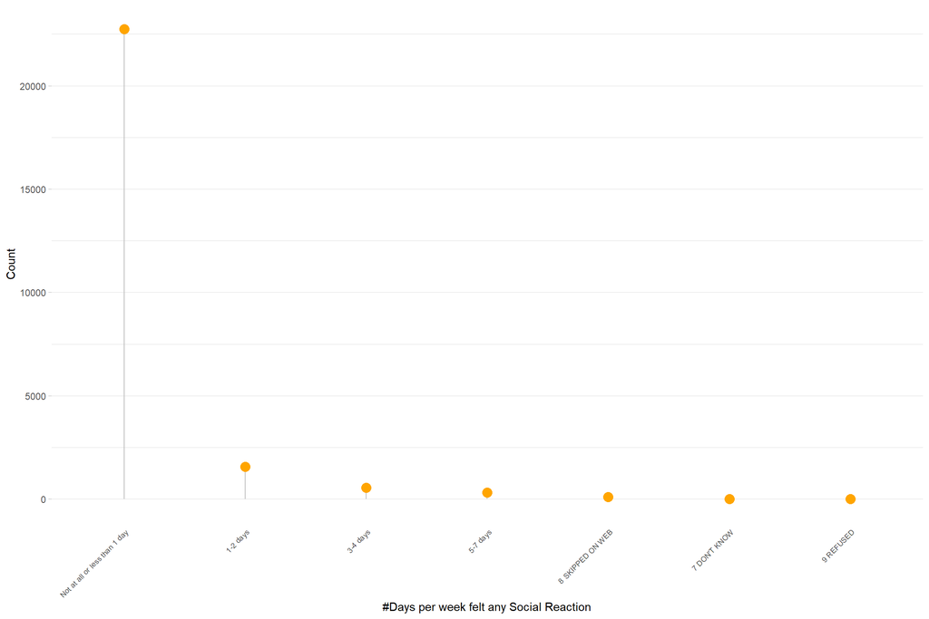

# Lifestyle Impact of COVID-19

The COVID-19 pandemic has led to a dramatic loss of human life worldwide and presents an unprecedented challenge to public health, food systems and the world of work. The economic and social disruption caused by the pandemic is devastating but so has been the effect on the lifestyle of people. Daily practices such as going to work or study, social gatherings, traveling etc has been altered and humans were forced to find alternatives such as work/study home, video calls, online streaming etc. to accommodated to the current situation.

To study the impact on lifestyle due to covid19 , people were asked if they have made any of the following changes in lifestyle, as a response to the coronavirus

### Practiced Safety Precautions

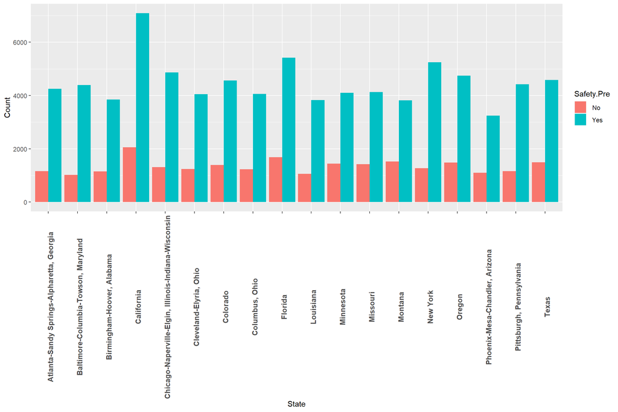

- The above graph shows the if people take any safety precautions for covid19 in their day-to-day life
- 126345 people were surveyed. 76% of the population chose “Yes” and 24% chose “No”
- California has the highest number of contributors to the “Yes” Category.

### Work/Study

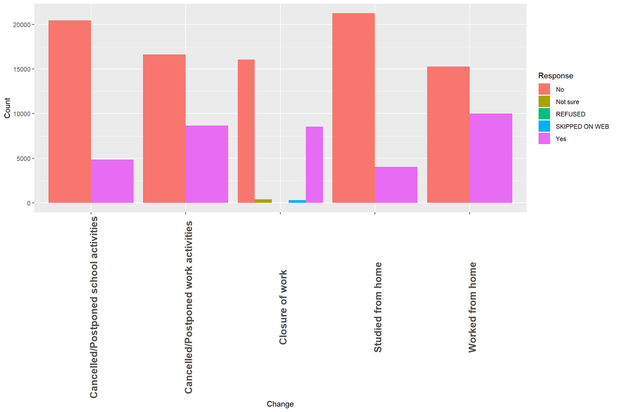

- The above graph shows the if people have made any changes to their work/study life, such as work from home, cancelled/postponed plans etc due to covid19
- 89598 out of 126345 people chose “No” which is aprx. 70% and aprx 28% of the people said “Yes”
- We can observe that the maximum contributor of “Yes” are the people who have worked from home.

### Travel

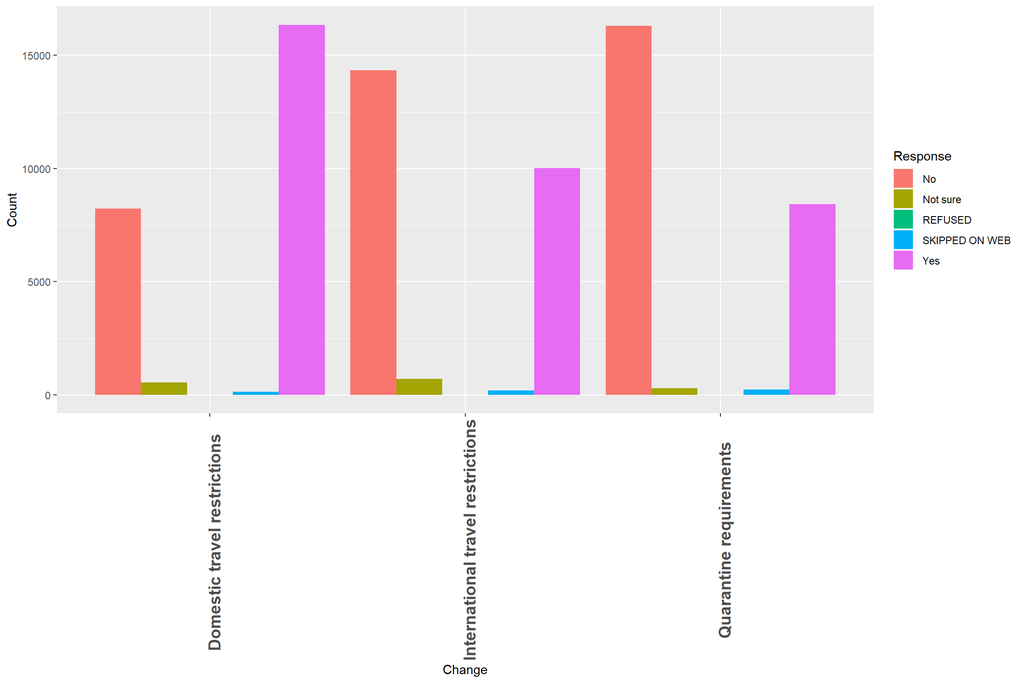

### Social Gathering/ Outing

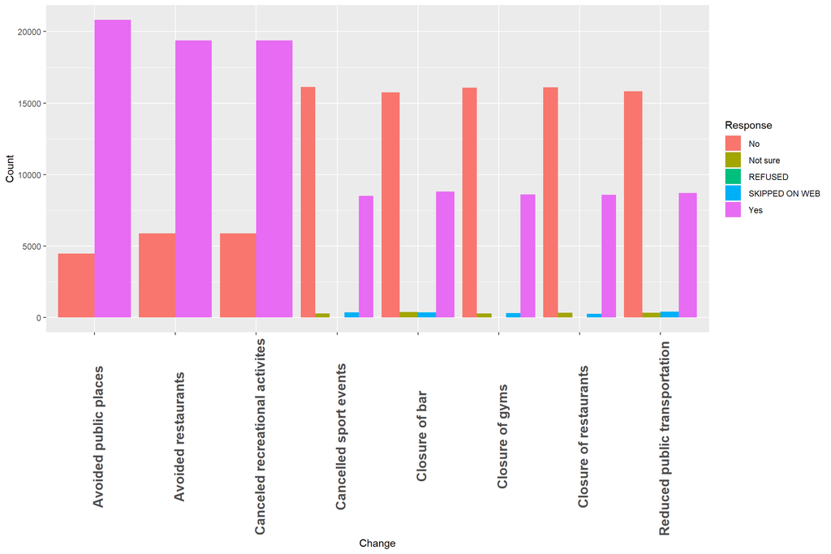

- The above graph shows if people have made any changes to their social gathering/outing plans due to covid19 restriction. Such as not being able go to the gym, reduced use of public transport or places etc
- 102789 out of 202152 people said “Yes” the have made changes to their travel plans, which is aprx. 50% and 47% chose “No”.
- We can observe that the major contributors of yes are avoided public places, avoiding restaurant and cancelation of recreational activities.

# Economical Impact of COVID-19

The COVID-19 pandemic had a huge impact on the economical conditions of the population. The reduction of business due to restrictions and change in the trade system has resulted in loss of jobs or other sources of incomes, which resulted in economic hardships. As a result, people reached out various government and non-government bodies for financial, social and lifestyle assistance.

In the below graph, a population group of 202152 were studied.

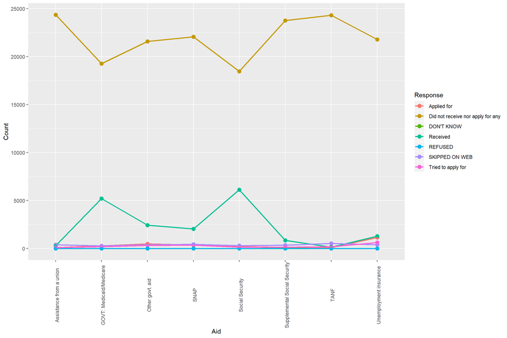

- We can observe that majority of the people did not receive nor applied for any economical assistance, which is aprx. 86% of the studied population.
- 9% of the population studied did receive assistance, i.e. 18401 people

# Conclusions

# References

- [Associated Press](https://apnews.com/)
- [CDC](https://cdc.gov/)
- [R Graph Gallery](https://www.r-graph-gallery.com/)